# Untitled

2026-06-03

### Figure of Summary of GO Assignments and Mean Correlation

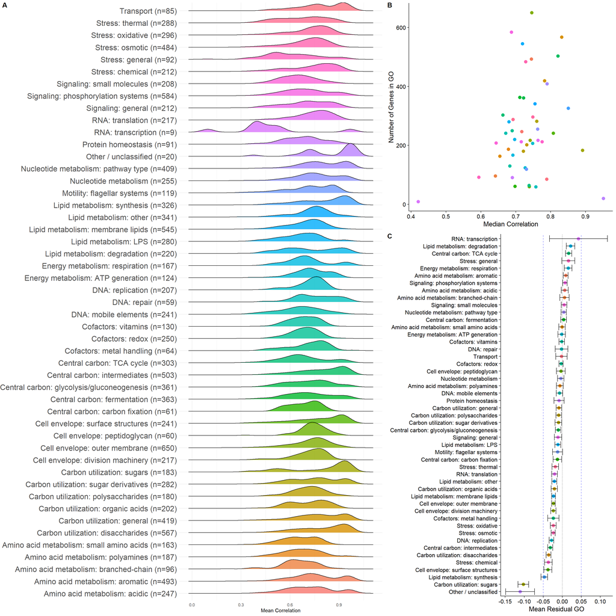

The distribution of Mean correlation varies across GO groups indicating that GO assigments represent a variety of biological functional categories. Differences in distribution shape likely reflect heterogeneity in transcriptional organization and pathway structure, although the specific regulatory mechanisms underlying these patterns cannot be determined from coexpression alone.

```
## $main
## # A tibble: 1 × 2
##    gene  edge
##   <dbl> <dbl>
## 1 0.483 0.434
##
## $sub
## # A tibble: 1 × 2
##    gene  edge
##   <dbl> <dbl>
## 1 0.349 0.223
```

### Figure of Biological and GO Recovery

```
## # A tibble: 25 × 2
##    Gene  GO_sub
##    <chr> <chr>
##  1 rpmH  RNA: translation
##  2 manX  Carbon utilization: sugar derivatives
##  3 rsmG  RNA: translation
##  4 menH  Cofactors: redox
##  5 glgX  Carbon utilization: polysaccharides
##  6 exbB  Cofactors: metal handling
##  7 ybdG  Stress: osmotic
##  8 insC2 DNA: mobile elements
##  9 cueO  Cofactors: metal handling
## 10 maoP  DNA: replication
## # ℹ 15 more rows
```

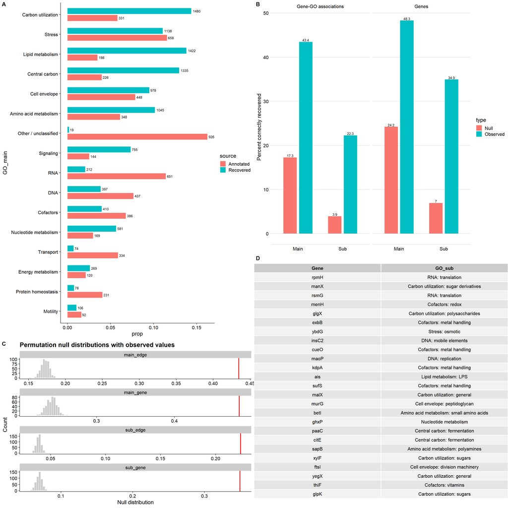

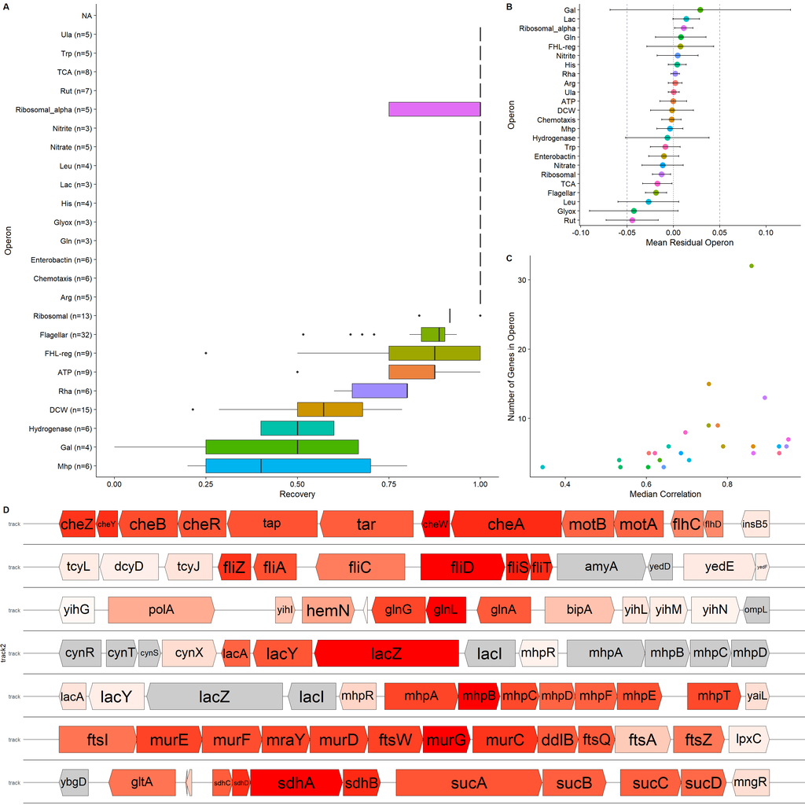

Operon membership count was moderately positively associated with median coexpression (r = 0.37, p = 0.076), which did not reach conventional significance. However, spearman rank correlation size was significant (ρ = 0.64, p = 7.8 × 10⁻4), indicating that operon size explains some of the variation in coexpression among operons. Interpretation of operon-level size effects should be made cautiously, as the operon recovery dataset contains relatively few large operons and only a single operon with more than 15 genes. Operon size alone is not the only driver of coexpression structure. These analysis demonstrates that top-ranked coexpression neighbors partially recover known operon structure. In many cases, genes within the same operon are enriched among the highest correlated partners, indicating that transcriptional coupling is detectable through the correlation framework. Because operon membership was not incorporated into the correlation calculations, the enrichment of operon partners among highly ranked neighbors provides an independent validation that biologically meaningful transcriptional structure is captured by the coexpression framework. Strenthening the idea that the use of this tool is likely to uncover biological signal when queried by an uncharacterized gene.

However, recovery is incomplete and variable across operons. Some operons show strong internal coherence, while others display diluted signal, likely reflecting:

- condition-dependent operon usage
- indirect co-regulation across regulons
- fragmentation of operon expression under heterogeneous conditions

Specifically, operons such as the flagellar operon, divison/cell wall cluster, and the gal operon all contain multiple promoters, terminators, and modulators of their transcriptional activity. Such regulatory complexity may contribute to reduced coexpression among genes within these operons, potentially explaining the lower recovery observed for some transcriptional units. Overall, these results indicate that coexpression captures operon structure as a noisy but meaningful signal, rather than a strict reconstruction of transcriptional units.

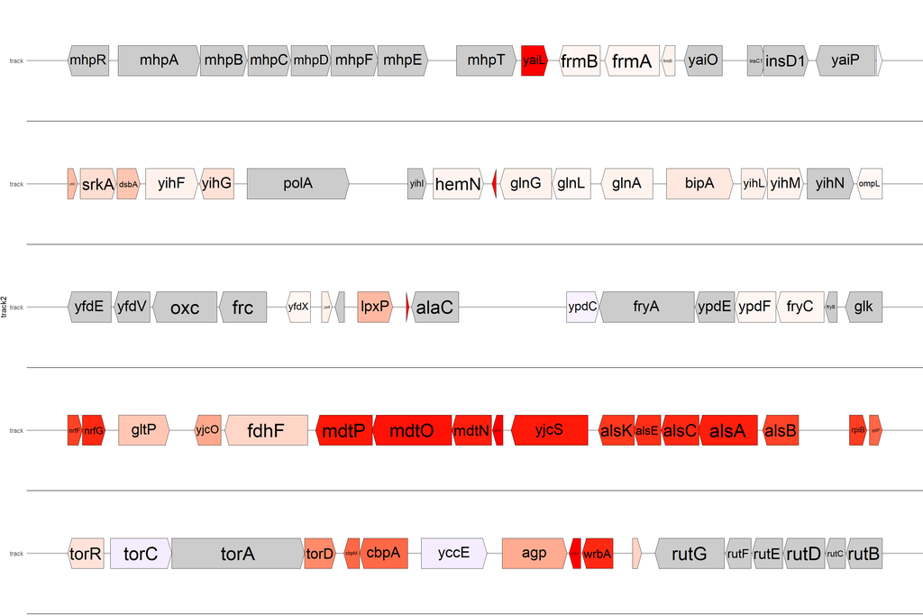

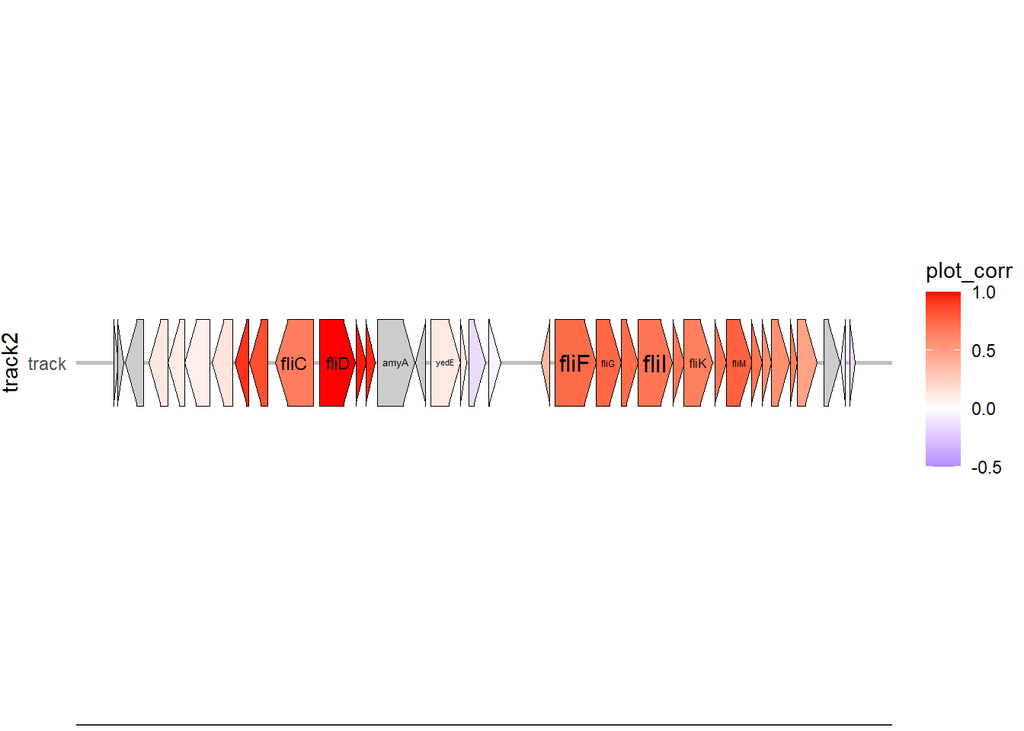